# Discussion for Week 2

## Built in data sets

R includes many built-in datasets. We saw this with the **MPG** and **diamods** datasets that are used in the *R for Data Science* book.

You can see all the datasets in the **The R Datasets Package** with the following command:

```r
data()
```

Often, other packages will include their own datasets.

For example, the textbook *Data Analysis and Graphics Using R* has a number of datasets and we can look those in the packages **DAAG** and **MASS** used in their textbook using the following command:

```r
data(package = "DAAG")
data(package = "MASS")
```

Lots of data to work with… If you’re tring to find information about a particular type of analysis, someone has probaly already worked out many of the details. (Of course, it may not use the most recent additions to R (i.e. the **tidyverrse** package, but it can be a good place to start.))

## How do I view the data?

There are two ways to view data: using the View() function, just typing the name of the dataset into the console window.

```r
library("DAAG")
View(greatLakes) # requires library("DAAG")
greatLakes
```

```
Time Series:
Start = 1918
End = 2009
Frequency = 1
         Erie michHuron  Ontario  StClair
1918 174.0150  176.8867 74.87250 174.9567
1919 174.1808  176.7450 74.95583 175.0767
1920 173.9083  176.6250 74.56750 174.8150
1921 174.0258  176.4883 74.66583 174.8692
1922 173.9275  176.4450 74.65667 174.8108
1923 173.7575  176.2642 74.44333 174.6525
1924 173.8433  176.1867 74.55750 174.6375
1925 173.5933  175.9192 74.39000 174.4058
1926 173.6408  175.8850 74.40250 174.4017
1927 173.8183  176.1483 74.60667 174.5983
```

[output cut: 82 more lines]

This is a timeseries dataset (more on that later). We can try to convert it to a tibble (data frame) using the as.tibble() function

```r
gL <- as.tibble(greatLakes)
gL
```

| Erie | michHuron | Ontario | StClair |
| --- | --- | --- | --- |
| 174.0150 | 176.8867 | 74.87250 | 174.9567 |
| 174.1808 | 176.7450 | 74.95583 | 175.0767 |
| 173.9083 | 176.6250 | 74.56750 | 174.8150 |
| 174.0258 | 176.4883 | 74.66583 | 174.8692 |
| 173.9275 | 176.4450 | 74.65667 | 174.8108 |
| 173.7575 | 176.2642 | 74.44333 | 174.6525 |
| 173.8433 | 176.1867 | 74.55750 | 174.6375 |
| 173.5933 | 175.9192 | 74.39000 | 174.4058 |
| 173.6408 | 175.8850 | 74.40250 | 174.4017 |
| 173.8183 | 176.1483 | 74.60667 | 174.5983 |

[output cut: 82 more lines]

We see that we’ve lost the year information (this was automatically generated in the time series data set… so we’d want to add that back at somepoint)

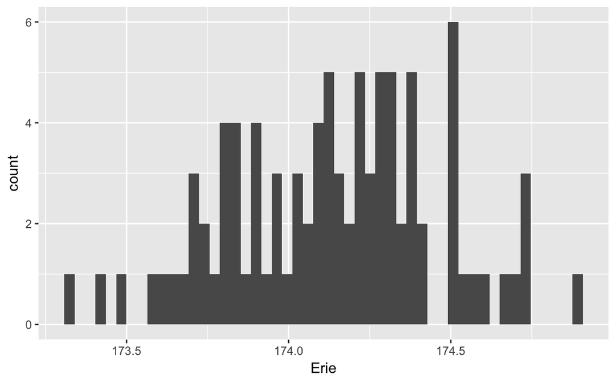

```r
ggplot(data = gL) +
  geom_histogram(mapping = aes(Erie), bins = 50)
```

If I want info on the dataset, I use the following command:

```r
?greatLakes
```

As much a I like ggplot(), if I want to look at TS data, I’ll need to use the base graphics plot()

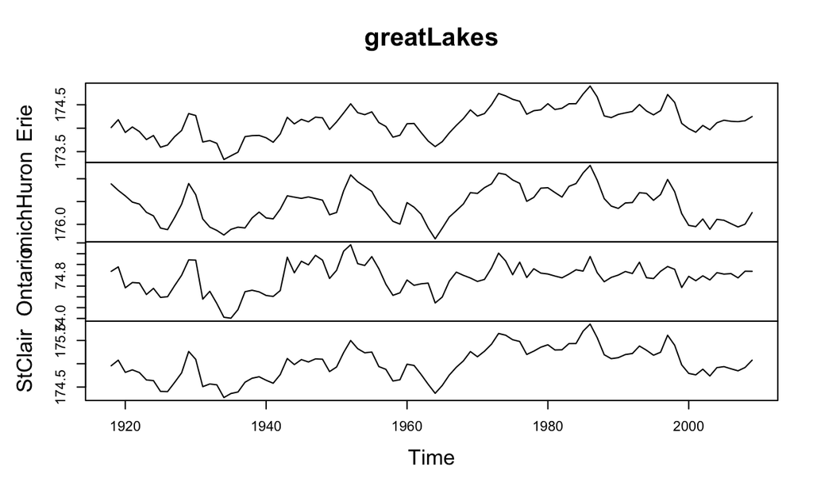

```r
plot(greatLakes)
```